# Peer Assessment 1 (Activity monitoring data)

by Peter Zhilyaev

## Introduction

This assignment makes use of data from a personal activity monitoring device. This device collects data at 5 minute intervals through out the day. The data consists of two months of data from an anonymous individual collected during the months of October and November, 2012 and include the number of steps taken in 5 minute intervals each day.

## Data

The data for this assignment can be downloaded from the course web site:

- **Dataset**: [Activity monitoring data](https://d396qusza40orc.cloudfront.net/repdata%2Fdata%2Factivity.zip) [52K]

The variables included in this dataset are:

- **steps**: Number of steps taking in a 5-minute interval (missing values are coded as *NA*)
- **date**: The date on which the measurement was taken in YYYY-MM-DD format
- **interval**: Identifier for the 5-minute interval in which measurement was taken

The dataset is stored in a comma-separated-value (CSV) file and there are a total of 17,568 observations in this dataset.

## Assignment

This assignment will be described in multiple parts. You will need to write a report that answers the questions detailed below. Ultimately, you will need to complete the entire assignment in a **single R markdown** document that can be processed by **knitr** and be transformed into an HTML file.

Throughout your report make sure you always include the code that you used to generate the output you present. When writing code chunks in the R markdown document, always use *echo = TRUE* so that someone else will be able to read the code. **This assignment will be evaluated via peer assessment so it is essential that your peer evaluators be able to review the code for your analysis.**

For the plotting aspects of this assignment, feel free to use any plotting system in R (i.e., base, lattice, ggplot2)

Fork/clone the [GitHub repository created for this assignment](http://github.com/rdpeng/RepData_PeerAssessment1). You will submit this assignment by pushing your completed files into your forked repository on GitHub. The assignment submission will consist of the URL to your GitHub repository and the SHA-1 commit ID for your repository state.

NOTE: The GitHub repository also contains the dataset for the assignment so you do not have to download the data separately.

### Loading and preprosessing the data

```r
# I'm using dplyr
library(dplyr)
unzip('activity.zip')
# Check if unzipping occurs correct
if (!file.exists('activity.csv')) { print("Error: something wrong with the zip archive")}

activity <- tbl_df(read.csv('activity.csv'))

# Removing activity.csv:
file.remove('activity.csv')
```

```
## [1] TRUE
```

### What is mean total number of steps taken per day?

Calculate the total number of steps taken per day:

```r
# Grouping acitivity by date
activityByDate <- group_by(activity, date)
# Summarizing steps per day
stepsPerDay <- summarize(activityByDate, steps = sum(steps))
stepsPerDay
```

```
## Source: local data frame [61 x 2]
##
##          date steps
## 1  2012-10-01    NA
## 2  2012-10-02   126
## 3  2012-10-03 11352
## 4  2012-10-04 12116
## 5  2012-10-05 13294
## 6  2012-10-06 15420
## 7  2012-10-07 11015
## 8  2012-10-08    NA
## 9  2012-10-09 12811
## 10 2012-10-10  9900
## ..        ...   ...
```

Make a histogram of the total number of steps taken each day:

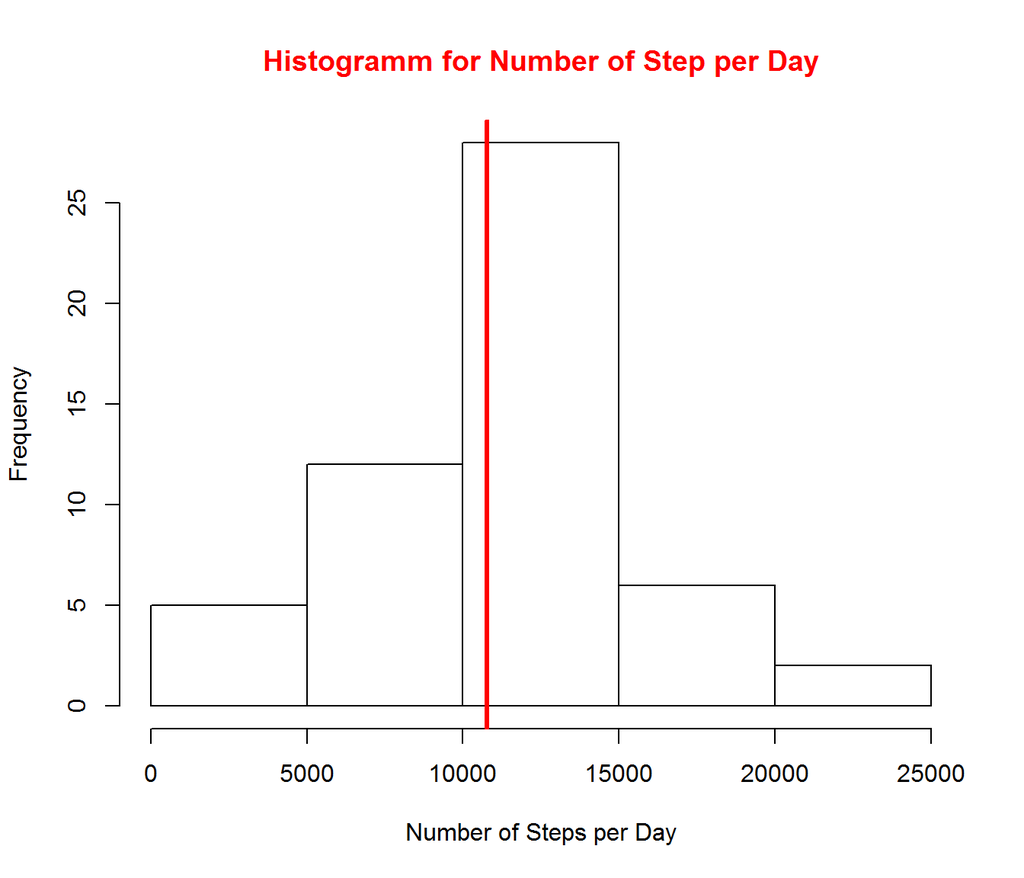

```r
par(col.main="red")
with(stepsPerDay, hist(steps, main="Histogramm for Number of Step per Day", xlab="Number of Steps per Day"))
abline(v=mean(stepsPerDay$steps, na.rm=TRUE), lwd=3, lty=2, col="red")
abline(v=median(stepsPerDay$steps, na.rm=TRUE), lwd=3, lty=1, col="red")
```

Calculate and report the mean and median of the total number of steps taken per day

```r
# Mean number of steps per day
oldMean <- mean(stepsPerDay$steps, na.rm=TRUE)
oldMean
```

```
## [1] 10766.19
```

```r
# Median number of steps per day
oldMedian <- median(stepsPerDay$steps, na.rm=TRUE)
oldMedian
```

```
## [1] 10765
```

### What is the average daily activity pattern?

Make a time series plot (i.e. type = “l”) of the 5-minute interval (x-axis) and the average number of steps taken, averaged across all days (y-axis)

```r
activityByInterval <- group_by(activity, interval)
# Changing steps = NA with steps = 0
activityByInterval$steps[is.na(activityByInterval$steps)] <- 0
stepsByInterval <- summarize(activityByInterval, steps=mean(steps))
# Numerate interval by numbers 1, 2, ...
stepsByInterval$interval <- 1:length(stepsByInterval$interval)
```

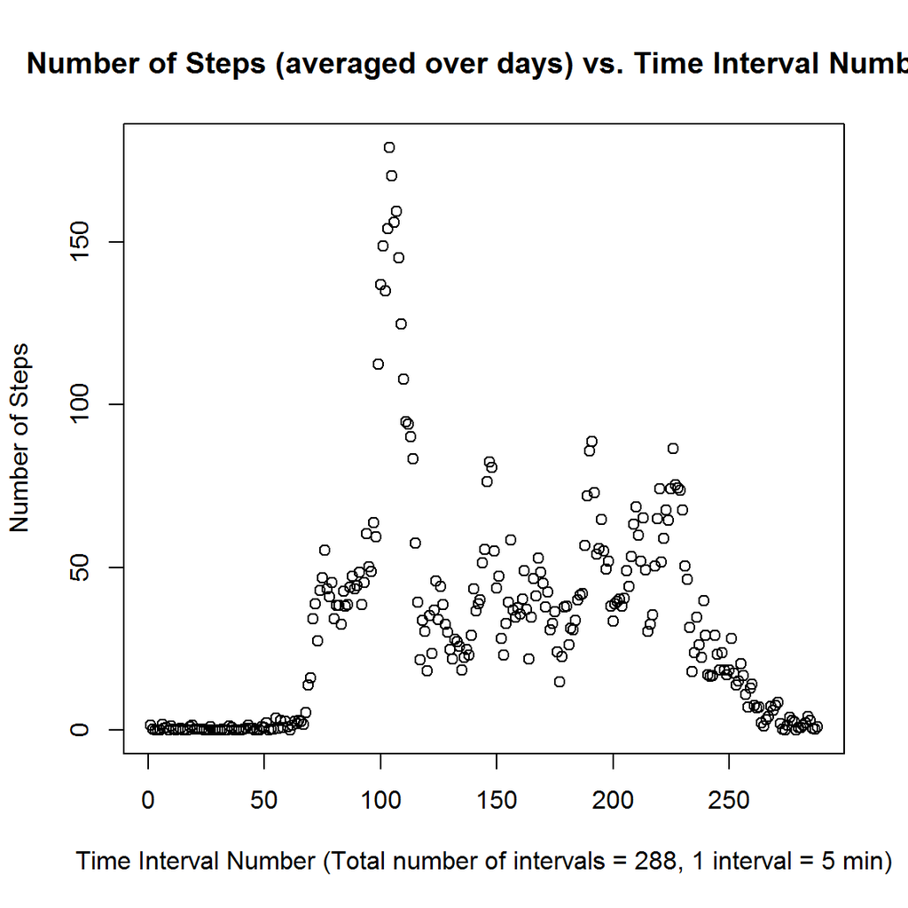

```r
with(stepsByInterval, plot(interval, steps, main="Number of Steps (averaged over days) vs. Time Interval Number", xlab="Time Interval Number (Total number of intervals = 288, 1 interval = 5 min)", ylab = "Number of Steps"))
```

Which 5-minute interval, on average across all the days in the dataset, contains the maximum number of steps?

```r
# 5-minute interval taht contains the maximum number of steps
filter(stepsByInterval, steps == max(steps))$interval
```

```
## [1] 104
```

### Imputing missing values

Calculate and report the total number of missing values in the dataset (i.e. the total number of rows with NAs):

```r
# Total number of NAs
whereNA <- is.na(activity$steps)
sum(whereNA)
```

```
## [1] 2304
```

Devise a strategy for filling in all of the missing values in the dataset. The strategy does not need to be sophisticated. For example, you could use the mean/median for that day, or the mean for that 5-minute interval, et. **My strategy is to fill missing values with values of steps for corresponding 5-minute interval averaging over all days**

```r
#activity$interval[whereNA]

# Again creating data frame activityByInterval
# This time we won't change the interval values
activityByInterval <- group_by(activity, interval)
# Changing steps = NA with steps = 0
activityByInterval$steps[is.na(activityByInterval$steps)] <- 0
stepsByInterval <- summarize(activityByInterval, steps=mean(steps))

# Create the function that will help to map intervals to average step over all days
fun <- function(x) {
        return(stepsByInterval[stepsByInterval$interval == x, ]$steps)
}

x <- as.numeric(activity$interval[whereNA])
# Mappint intervals to steps
y <- sapply(x, fun, simplify = "array")
```

Create a new dataset that is equal to the original dataset but with the missing data filled in.

```r
newActivity <- activity
# Substituting NAs with y ( )
newActivity$steps[whereNA] <- y
# No NAs
head(newActivity)
```

```
## Source: local data frame [6 x 3]
##
##        steps       date interval
## 1 1.49180328 2012-10-01        0
## 2 0.29508197 2012-10-01        5
## 3 0.11475410 2012-10-01       10
## 4 0.13114754 2012-10-01       15
## 5 0.06557377 2012-10-01       20
## 6 1.81967213 2012-10-01       25
```

Make a histogram of the total number of steps taken each day and Calculate and report the mean and median total number of steps taken per day. Do these values differ from the estimates from the first part of the assignment? What is the impact of imputing missing data on the estimates of the total daily number of steps?

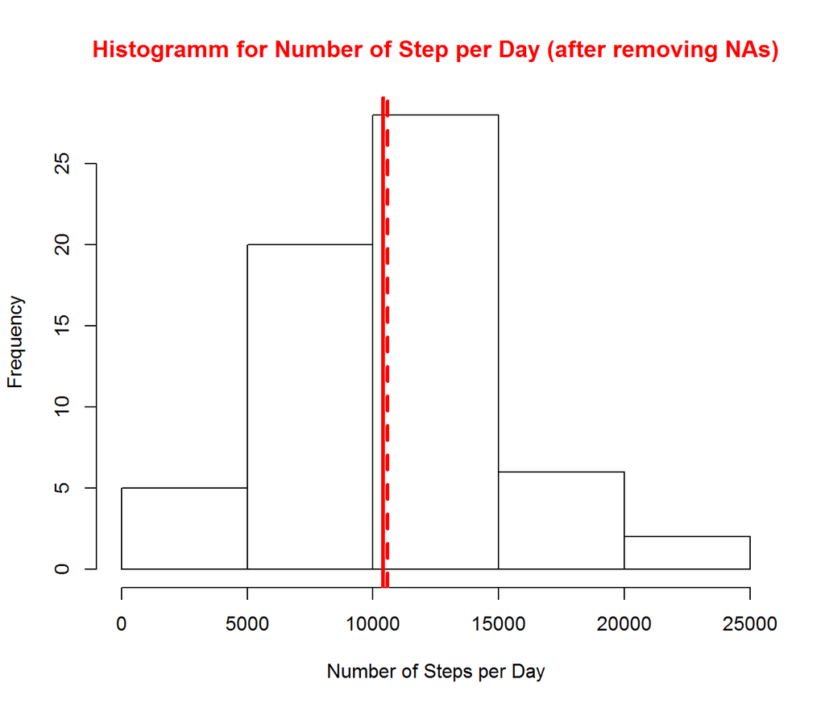

```r
# Again creating activityByData but now without NAs values
# Grouping acitivity by date
newActivityByDate <- group_by(newActivity, date)
# Summarizing steps per day
stepsPerDay <- summarize(newActivityByDate, steps = sum(steps))

par(col.main="red")
with(stepsPerDay, hist(steps, main="Histogramm for Number of Step per Day (after removing NAs)", xlab="Number of Steps per Day"))
abline(v=mean(stepsPerDay$steps, na.rm=TRUE), lwd=3, lty=2, col="red")
abline(v=median(stepsPerDay$steps, na.rm=TRUE), lwd=3, lty=1, col="red")
```

```r
# Mean number of steps per day
newMean <- mean(stepsPerDay$steps, na.rm=TRUE)
# Median number of steps per day
newMedian <- median(stepsPerDay$steps, na.rm=TRUE)
```

The obtained value differes from previous in %:

```r
(oldMedian - newMedian) / oldMedian * 100
```

```
## [1] 3.437065
```

```r
(oldMean - newMean) / oldMean * 100
```

```
## [1] 1.719968
```

Hence the difference is rather small around 2 and 3 percents.

### Are there differences in activity patterns between weekdays and weekends?

For this part the weekdays() function may be of some help here. Use the dataset with the filled-in missing values for this part.

Create a new factor variable in the dataset with two levels – “weekday” and “weekend” indicating whether a given date is a weekday or weekend day.

```r
dateToWeekday <- function(x) {
        day = weekdays(as.Date(x), abbreviate=FALSE)
        if (day == "воскресенье" | day == "суббота") {
                return("weekend")
        }
        else {return("weekday")}
}


day <- sapply(newActivity$date, dateToWeekday, simplify='array')
newActivity <- cbind(newActivity, day)
newActivitySummary <- summarize(group_by(newActivity, interval, day), steps=mean(steps))

# Numerate interval by numbers 1, 2, ...
newActivitySummary <- newActivitySummary %>% ungroup() %>% arrange(day)

# Proper numeration of intervals
x <- 1:(length(newActivitySummary$interval)/2)
newActivitySummary$interval <- c(x,x)

head(newActivitySummary)
```

```
## Source: local data frame [6 x 3]
##
##   interval     day      steps
## 1        1 weekday 2.22112933
## 2        2 weekday 0.43934426
## 3        3 weekday 0.17085610
## 4        4 weekday 0.19526412
## 5        5 weekday 0.09763206
## 6        6 weekday 1.55373406
```

Make a panel plot containing a time series plot (i.e. type = “l”) of the 5-minute interval (x-axis) and the average number of steps taken, averaged across all weekday days or weekend days (y-axis). See the README file in the GitHub repository to see an example of what this plot should look like using simulated data.

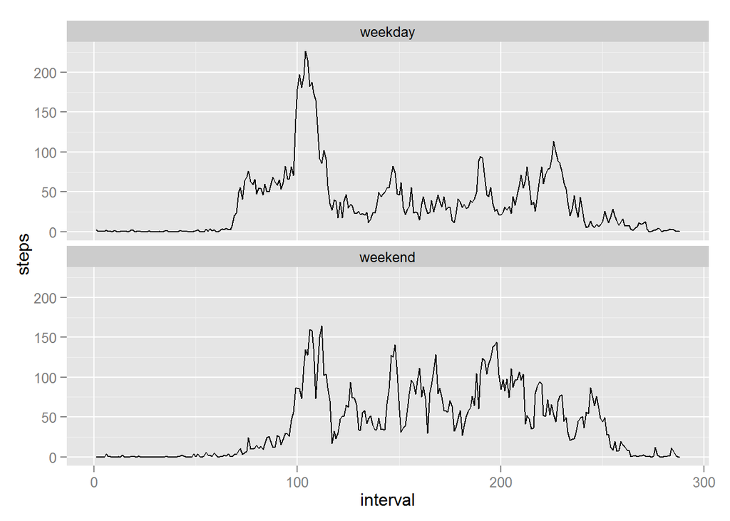

```r
# Using ggplot2
library(ggplot2)
qplot(interval, steps, data=newActivitySummary, geom=c("line")) + facet_wrap(~ day, ncol=1)
```